# Multivariate Assignment - 1 v1

Elena Ortega - Damiano Alessi - Xieru Song - Aharon V. Zúñiga.

October - 2020

# Descriptive & Basis analysis

### Descriptive & Basis analysis

Here is a descriptive analysis in order to get information.

```r
load("wvs.Rdata")
summary(wvs[,1:10])
```

```
##    V_creative      V_rich         V_secure     V_spoil_oneself   V_do_good
##  Min.   :1.0   Min.   :1.000   Min.   :1.000   Min.   :1.000   Min.   :1.000
##  1st Qu.:3.0   1st Qu.:2.000   1st Qu.:4.000   1st Qu.:3.000   1st Qu.:4.000
##  Median :4.0   Median :3.000   Median :5.000   Median :4.000   Median :5.000
##  Mean   :4.3   Mean   :3.211   Mean   :4.673   Mean   :3.797   Mean   :4.598
##  3rd Qu.:5.0   3rd Qu.:4.000   3rd Qu.:6.000   3rd Qu.:5.000   3rd Qu.:6.000
##  Max.   :6.0   Max.   :6.000   Max.   :6.000   Max.   :6.000   Max.   :6.000
##  V_be_successful V_exciting_life V_behave_properly V_protect_environment
##  Min.   :1.000   Min.   :1.000   Min.   :1.000     Min.   :1.000
##  1st Qu.:3.000   1st Qu.:2.000   1st Qu.:4.000     1st Qu.:4.000
##  Median :4.000   Median :3.000   Median :5.000     Median :5.000
##  Mean   :4.088   Mean   :3.363   Mean   :4.501     Mean   :4.563
##  3rd Qu.:5.000   3rd Qu.:5.000   3rd Qu.:6.000     3rd Qu.:6.000
##  Max.   :6.000   Max.   :6.000   Max.   :6.000     Max.   :6.000
##   V_tradition
##  Min.   :1.000
##  1st Qu.:4.000
##  Median :5.000
##  Mean   :4.485
##  3rd Qu.:6.000
##  Max.   :6.000
```

```r
zscore <- function(x) {
  zscore <- (x-mean(x))/sd(x)
  }
```

# 4. Structural equation model (SEM)

### Structural equation model (SEM)

Continue working on the data of the countries “Netherlands” and “Malaysia”. Estimate a structural equation model to investigate how the importance of religion affects the justifiability of behaviors for respondents. Does the result of the analysis differ for respondents of the two countries?

After filtering the countries Netherlands and Malaysia from the data, a structural equation model was conducted to this data.

```r
raw_country <- wvs[wvs$country %in% c("Netherlands","Malaysia"),]
```

Firstly we did a model with 3 latent variables verified in previous analysis ( **Interpersonal**, **Financial**, **Violence**) and we add a fourth one called religious which one used the following manifest variables **R_attend_religious_services**, **R_pray** and **R_importance_God**.

```r
#In order to make the model identifiable, loadings for the first manifest variables of each factor are constraint to 1, in that way variances of factors are estimated freely.
#Additionally, we include three regressions in order to understand how religious variable interact with the other latent variables.
sem1<- 'Interpersonal =~ 1*J_homosexuality+J_prostitution+J_abortion+J_divorce+J_sex_before_marriage+J_suicide
   Financial =~ 1*J_claiming_benefits+J_avoiding_fare+J_stealing_property+J_cheating_taxes+J_accept_bribe
   Violence =~ 1*J_beat_wife+ J_parents_beating_children+J_violence
   Financial ~~ Violence
   Violence =~ J_suicide
   Violence =~ J_prostitution
   Religious =~ 1*R_attend_religious_services + R_pray + R_importance_God
   Interpersonal ~ Religious
   Financial ~ Religious
   Violence ~ Religious
'
```

In order to attend our parameters needed, is necessary to create a structure and filter the data into it.

```r
#Creating vectors to use as a columns
Interpersonal <- c("J_homosexuality","J_prostitution","J_abortion","J_divorce","J_sex_before_marriage","J_suicide")
Financial <- c("J_claiming_benefits","J_avoiding_fare","J_stealing_property","J_cheating_taxes","J_accept_bribe")
Violence  <- c("J_beat_wife", "J_parents_beating_children","J_violence")
Religious <- c("R_attend_religious_services" , "R_pray" , "R_importance_God")

#Filter data by country
raw_country <- wvs[wvs$country %in% c("Netherlands","Malaysia"),]
#Create dataframe
raw_data <- apply(raw_country[,c(Interpersonal, Financial, Violence, Religious)],2,zscore)
#Joining filter data and bulk it into a new dataframe
raw_data_c <- cbind(raw_data,raw_country)
```

When we use the data of both countries with the Structural Equation Model, the **CFI is 0.961** and **TLI is 0.953**; both values are **greater than 0.95**, which means that the model has a good fit. Then **RMSEA** obtained a **value of 0.070**, which means that is a good fit as well, because it is **lower than 0.08**.

```r
#Fit Structural Equation Models, using as a parameter sem1 and filtering data. Is not using a covariance matrix because it will be use a country as a column.
fitsem1<-sem(sem1,data = raw_data_c)
#check Summary
summary(fitsem1, fit.measures=TRUE)
```

```
## lavaan 0.6-7 ended normally after 45 iterations
##
##   Estimator                                         ML
##   Optimization method                           NLMINB
##   Number of free parameters                         42
##
##   Number of observations                          2473
##
## Model Test User Model:
##
##   Test statistic                              1470.812
##   Degrees of freedom                               111
##   P-value (Chi-square)                           0.000
##
## Model Test Baseline Model:
##
##   Test statistic                             35235.961
##   Degrees of freedom                               136
##   P-value                                        0.000
##
## User Model versus Baseline Model:
##
##   Comparative Fit Index (CFI)                    0.961
##   Tucker-Lewis Index (TLI)                       0.953
##
## Loglikelihood and Information Criteria:
##
##   Loglikelihood user model (H0)             -42762.518
##   Loglikelihood unrestricted model (H1)     -42027.112
##
##   Akaike (AIC)                               85609.036
##   Bayesian (BIC)                             85853.190
##   Sample-size adjusted Bayesian (BIC)        85719.746
##
## Root Mean Square Error of Approximation:
##
##   RMSEA                                          0.070
##   90 Percent confidence interval - lower         0.067
##   90 Percent confidence interval - upper         0.074
##   P-value RMSEA <= 0.05                          0.000
```

[output cut: 62 more lines]

```
##    .J_clamng_bnfts    0.377    0.012   30.162    0.000
##    .J_avoiding_far    0.406    0.013   30.758    0.000
##    .J_stlng_prprty    0.192    0.009   22.334    0.000
##    .J_cheating_txs    0.409    0.013   30.804    0.000
##    .J_accept_bribe    0.298    0.011   27.934    0.000
##    .J_beat_wife       0.198    0.011   18.712    0.000
##    .J_prnts_btng_c    0.477    0.015   31.030    0.000
##    .J_violence        0.227    0.011   20.943    0.000
##    .R_ttnd_rlgs_sr    0.333    0.011   29.112    0.000
##    .R_pray            0.170    0.008   20.059    0.000
##    .R_importanc_Gd    0.211    0.009   23.303    0.000
##    .Interpersonal     0.302    0.013   23.939    0.000
##    .Financial         0.602    0.026   22.910    0.000
##    .Violence          0.780    0.029   27.286    0.000
##     Religious         0.667    0.028   24.201    0.000
```

```r
#standardized solution
#standardizedSolution(fitsem1)
```

With those result we can conclude that this model is reliable for analysis. Now, we will review the result for regression analysis.

The variable **religious** has a **P value** **lower than 0.05** for the three regressions, this means that there is enough evidence **to reject the null hypothesis** that the estimate is **0**. We can conclude that the religious variable has an impact into Interpersonal, Financial and Violence variables. In addition, is possible to say for two variables this impact is positive, however, for the other variable, (Interpersonal) is the opposite.

## Comparison : Netherland & Malaysia

To see this relationship is maintain in the same analysis for both country in a separate way, we will use the same model for each country separately.

The results are the followings

### Netherland

```r
#Firstly, filter data
fitsem_n <- sem(sem1,data = raw_data_c[raw_data_c$country %in% c("Netherlands"),])
#Secondly, analyse summary
summary(fitsem_n, fit.measures=TRUE)
```

```
## lavaan 0.6-7 ended normally after 53 iterations
##
##   Estimator                                         ML
##   Optimization method                           NLMINB
##   Number of free parameters                         42
##
##   Number of observations                          1260
##
## Model Test User Model:
##
##   Test statistic                               615.928
##   Degrees of freedom                               111
##   P-value (Chi-square)                           0.000
##
## Model Test Baseline Model:
##
##   Test statistic                              8959.209
##   Degrees of freedom                               136
##   P-value                                        0.000
##
## User Model versus Baseline Model:
##
##   Comparative Fit Index (CFI)                    0.943
##   Tucker-Lewis Index (TLI)                       0.930
##
## Loglikelihood and Information Criteria:
##
##   Loglikelihood user model (H0)             -20283.747
##   Loglikelihood unrestricted model (H1)     -19975.783
##
##   Akaike (AIC)                               40651.495
##   Bayesian (BIC)                             40867.327
##   Sample-size adjusted Bayesian (BIC)        40733.915
##
## Root Mean Square Error of Approximation:
##
##   RMSEA                                          0.060
##   90 Percent confidence interval - lower         0.055
##   90 Percent confidence interval - upper         0.065
##   P-value RMSEA <= 0.05                          0.000
```

[output cut: 62 more lines]

```
##    .J_clamng_bnfts    0.248    0.011   22.568    0.000
##    .J_avoiding_far    0.412    0.019   22.122    0.000
##    .J_stlng_prprty    0.122    0.007   17.227    0.000
##    .J_cheating_txs    0.407    0.020   20.845    0.000
##    .J_accept_bribe    0.284    0.014   20.663    0.000
##    .J_beat_wife       0.199    0.011   18.504    0.000
##    .J_prnts_btng_c    0.325    0.017   18.794    0.000
##    .J_violence        0.215    0.015   14.524    0.000
##    .R_ttnd_rlgs_sr    0.205    0.011   19.204    0.000
##    .R_pray            0.142    0.011   12.465    0.000
##    .R_importanc_Gd    0.212    0.013   16.791    0.000
##    .Interpersonal     0.214    0.016   13.515    0.000
##    .Financial         0.086    0.010    8.489    0.000
##    .Violence          0.190    0.015   12.519    0.000
##     Religious         0.431    0.025   17.267    0.000
```

```r
#standardized solution
#standardizedSolution(fitsem_n)
```

Here an explanatory graph.

```r
semPaths(fitsem_n,"model","std","lisrel", edge.label.cex = 1.2, intercepts = FALSE, layout = "tree2",
panelGroups = FALSE, ask = FALSE, groups = "latent", pastel = TRUE, exoCov = TRUE, rotation = 1)
```

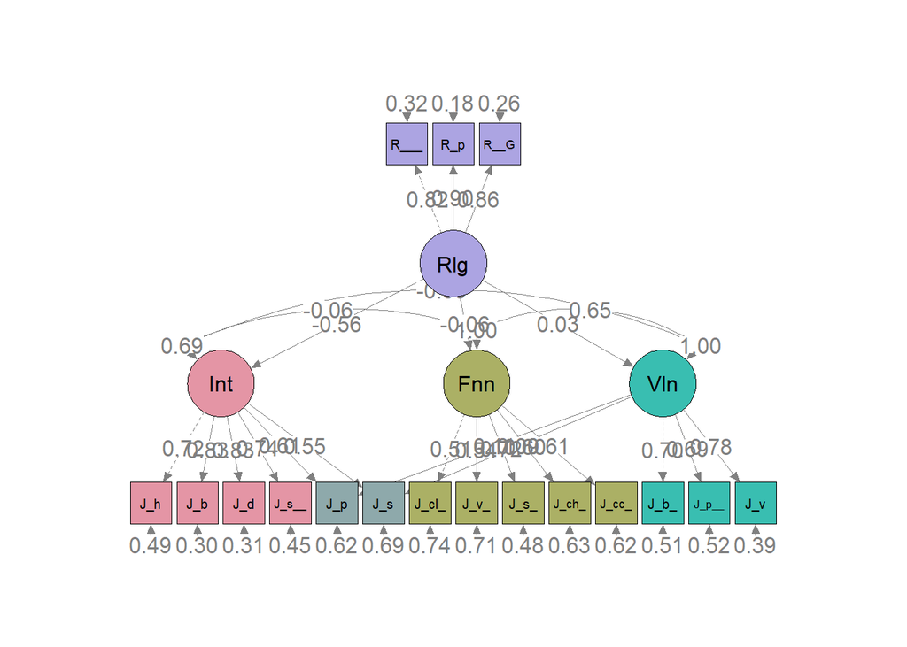

### Malaysia

```r
#Firstly, filter data
fitsem_m <- sem(sem1,data = raw_data_c[raw_data_c$country %in% c("Malaysia"),])
#Secondly, analyse summary
summary(fitsem_m, fit.measures=TRUE)
```

```
## lavaan 0.6-7 ended normally after 69 iterations
##
##   Estimator                                         ML
##   Optimization method                           NLMINB
##   Number of free parameters                         42
##
##   Number of observations                          1213
##
## Model Test User Model:
##
##   Test statistic                              1421.370
##   Degrees of freedom                               111
##   P-value (Chi-square)                           0.000
##
## Model Test Baseline Model:
##
##   Test statistic                             18131.501
##   Degrees of freedom                               136
##   P-value                                        0.000
##
## User Model versus Baseline Model:
##
##   Comparative Fit Index (CFI)                    0.927
##   Tucker-Lewis Index (TLI)                       0.911
##
## Loglikelihood and Information Criteria:
##
##   Loglikelihood user model (H0)             -17627.161
##   Loglikelihood unrestricted model (H1)     -16916.476
##
##   Akaike (AIC)                               35338.321
##   Bayesian (BIC)                             35552.557
##   Sample-size adjusted Bayesian (BIC)        35419.148
##
## Root Mean Square Error of Approximation:
##
##   RMSEA                                          0.099
##   90 Percent confidence interval - lower         0.094
##   90 Percent confidence interval - upper         0.103
##   P-value RMSEA <= 0.05                          0.000
```

[output cut: 62 more lines]

```
##    .J_clamng_bnfts    0.468    0.022   21.623    0.000
##    .J_avoiding_far    0.407    0.019   21.098    0.000
##    .J_stlng_prprty    0.247    0.015   16.584    0.000
##    .J_cheating_txs    0.360    0.017   20.631    0.000
##    .J_accept_bribe    0.316    0.016   19.188    0.000
##    .J_beat_wife       0.211    0.013   15.872    0.000
##    .J_prnts_btng_c    0.627    0.027   23.218    0.000
##    .J_violence        0.161    0.012   13.331    0.000
##    .R_ttnd_rlgs_sr    0.403    0.029   13.943    0.000
##    .R_pray            0.167    0.018    9.175    0.000
##    .R_importanc_Gd    0.179    0.008   22.160    0.000
##    .Interpersonal     0.149    0.010   14.406    0.000
##    .Financial         0.919    0.054   17.021    0.000
##    .Violence          1.234    0.059   20.896    0.000
##     Religious         0.301    0.033    8.996    0.000
```

```r
#standardized solution
#standardizedSolution(fitsem_n)
```

Explanatory graph

```r
semPaths(fitsem_m,"model","std","lisrel", edge.label.cex = 1.2, intercepts = FALSE, layout = "tree2",
panelGroups = FALSE, ask = FALSE, groups = "latent", pastel = TRUE, exoCov = TRUE, rotation = 1)
```

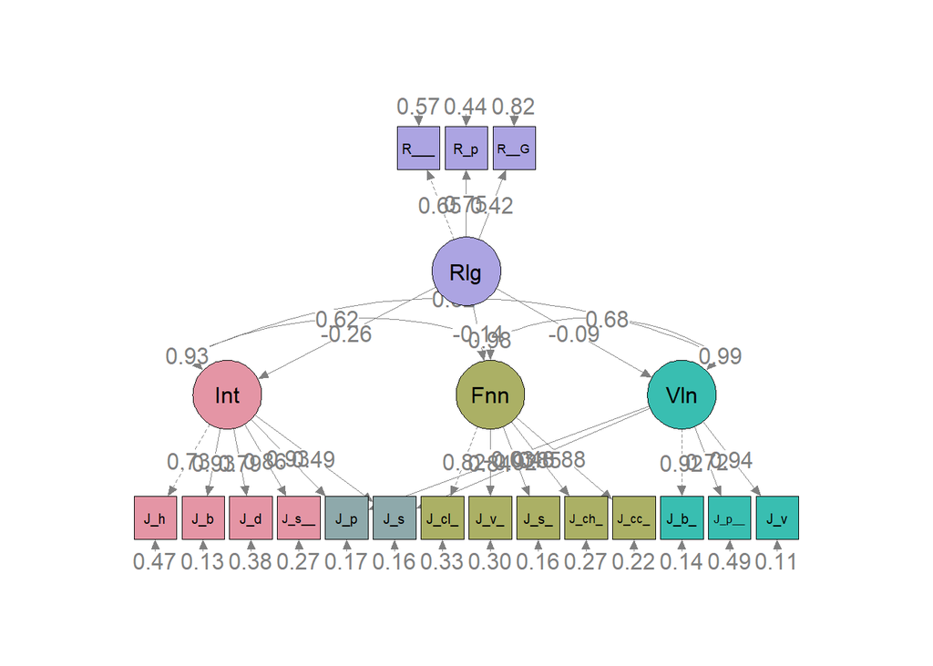

# 5. Canonical Correlation Analysis

### Canonical correlation analysis

Conduct the analysis on standardized items using the data of the countries “Netherlands” and “Malaysia”.

Here the first step creating both set of variables

```r
 set_x <- c("R_attend_religious_services","R_pray","R_importance_God", "CR_robberies", "CR_alcohol", "CR_police_military", "CR_racist_behavior", "CR_drug_sale")

set_y <- c("J_avoiding_fare", "J_stealing_property", "J_cheating_taxes", "J_accept_bribe", "J_homosexuality", "J_prostitution", "J_abortion", "J_divorce", "J_sex_before_marriage", "J_suicide", "J_beat_wife", "J_parents_beating_children", "J_violence")

ds <- wvs[wvs$country %in% c("Netherlands","Malaysia"),c(set_x, set_y, "country")]
str(ds)
```

```
## 'data.frame':    2473 obs. of  22 variables:
##  $ R_attend_religious_services: num  7 7 6 7 2 7 2 7 2 2 ...
##  $ R_pray                     : num  8 8 8 8 2 8 8 7 2 2 ...
##  $ R_importance_God           : num  10 10 10 10 8 10 10 10 10 8 ...
##  $ CR_robberies               : num  2 2 2 1 3 1 1 1 3 2 ...
##  $ CR_alcohol                 : num  2 1 1 1 1 1 1 2 2 2 ...
##  $ CR_police_military         : num  1 1 1 1 1 1 1 1 1 1 ...
##  $ CR_racist_behavior         : num  2 1 1 1 1 1 1 1 4 2 ...
##  $ CR_drug_sale               : num  2 1 2 1 1 1 1 1 2 2 ...
##  $ J_avoiding_fare            : num  1 1 1 9 2 8 2 8 7 2 ...
##  $ J_stealing_property        : num  1 1 1 1 2 1 1 2 6 1 ...
##  $ J_cheating_taxes           : num  1 1 1 1 2 1 6 5 9 2 ...
##  $ J_accept_bribe             : num  1 1 1 1 2 1 9 3 1 1 ...
##  $ J_homosexuality            : num  1 1 1 1 2 1 2 1 1 2 ...
##  $ J_prostitution             : num  1 1 1 1 2 1 1 1 1 2 ...
##  $ J_abortion                 : num  1 1 1 1 2 1 1 2 1 3 ...
##  $ J_divorce                  : num  1 1 1 1 2 1 5 2 1 4 ...
##  $ J_sex_before_marriage      : num  1 1 1 2 2 1 5 2 1 6 ...
##  $ J_suicide                  : num  1 1 1 2 2 1 3 2 1 1 ...
##  $ J_beat_wife                : num  1 1 1 2 2 1 5 1 1 1 ...
##  $ J_parents_beating_children : num  1 4 5 8 2 1 8 1 1 4 ...
##  $ J_violence                 : num  1 1 1 7 2 1 9 1 1 1 ...
##  $ country                    : Factor w/ 34 levels "Armenia","Australia",..: 15 15 15 15 15 15 15 15 15 15 ...
```

```r
#conduct canonical correlation analysis
cancor.out1<-cancor(x = ds[,set_x], y = ds[,set_y])
summary(cancor.out1)
```

```
##
## Canonical correlation analysis of:
##   8   X  variables:  R_attend_religious_services, R_pray, R_importance_God, CR_robberies, CR_alcohol, CR_police_military, CR_racist_behavior, CR_drug_sale
##   with    13   Y  variables:  J_avoiding_fare, J_stealing_property, J_cheating_taxes, J_accept_bribe, J_homosexuality, J_prostitution, J_abortion, J_divorce, J_sex_before_marriage, J_suicide, J_beat_wife, J_parents_beating_children, J_violence
##
##      CanR   CanRSQ    Eigen  percent    cum                          scree
## 1 0.77680 0.603414 1.521523 92.84477  92.84 ******************************
## 2 0.19660 0.038652 0.040206  2.45344  95.30 *
## 3 0.17159 0.029444 0.030337  1.85121  97.15 *
## 4 0.14810 0.021932 0.022424  1.36834  98.52
## 5 0.11646 0.013564 0.013750  0.83904  99.36
## 6 0.07256 0.005265 0.005293  0.32299  99.68
## 7 0.06397 0.004092 0.004108  0.25070  99.93
## 8 0.03373 0.001138 0.001139  0.06952 100.00
##
## Test of H0: The canonical correlations in the
## current row and all that follow are zero
##
##      CanR LR test stat approx F numDF   denDF   Pr(> F)
## 1 0.77680      0.35327  26.4998   104 16896.2 < 2.2e-16 ***
## 2 0.19660      0.89078   3.4113    84 15031.6 < 2.2e-16 ***
## 3 0.17159      0.92660   2.8561    66 13136.4 1.345e-13 ***
## 4 0.14810      0.95471   2.2881    50 11199.9 6.509e-07 ***
## 5 0.11646      0.97612   1.6549    36  9205.5  0.008181 **
## 6 0.07256      0.98954   1.0788    24  7126.6  0.359063
## 7 0.06397      0.99478   0.9210    14  4916.0  0.535026
## 8 0.03373      0.99886   0.4669     6  2459.0  0.833251
## ---
## Signif. codes:  0 '***' 0.001 '**' 0.01 '*' 0.05 '.' 0.1 ' ' 1
##
## Raw canonical coefficients
##
##    X  variables:
##                                  Xcan1     Xcan2     Xcan3     Xcan4     Xcan5
## R_attend_religious_services -0.1142662  0.449383 -0.141608  0.335472 -0.103053
## R_pray                      -0.0586761 -0.080686 -0.368975 -0.215344  0.032137
## R_importance_God            -0.1697199 -0.173554  0.391283  0.025268  0.069955
## CR_robberies                -0.2223940 -0.210444  0.065613 -0.519890 -0.935385
## CR_alcohol                   0.0910767 -0.032785  0.047595  0.740116  0.746901
## CR_police_military          -0.0176991 -1.417693 -0.792633  1.305883  0.349680
```

[output cut: 26 more lines]

```
## J_violence                 -0.0090586  0.0054354 -0.542139  0.357324 -0.0217428
##                                Ycan6      Ycan7     Ycan8
## J_avoiding_fare            -0.260311  0.1078333  0.122680
## J_stealing_property         0.096006  0.1364634  0.312153
## J_cheating_taxes           -0.025769  0.0230030 -0.125886
## J_accept_bribe             -0.194790 -0.0070072  0.066137
## J_homosexuality             0.154843 -0.0602302  0.046230
## J_prostitution             -0.078016  0.1476580 -0.377791
## J_abortion                  0.091869  0.3281518 -0.089542
## J_divorce                  -0.013757 -0.3527072  0.031173
## J_sex_before_marriage      -0.139343 -0.0377799  0.264442
## J_suicide                   0.063284  0.0742634  0.026393
## J_beat_wife                 0.648011  0.3014583  0.271586
## J_parents_beating_children  0.124807 -0.0590447 -0.021792
## J_violence                 -0.194543 -0.6164741 -0.377638
```

### 1. How many canonical correlations are significant?

The **H0 test** indicate that the **first five canonical** correlations are significant because, **Pr(>F)** is lower than significance level of **‘0.05’ (5%)**. This result shows that **H0**: **“The canonical correlations in the current row and all that follow are zero”**, thus can be rejected.

### 2. How can you interpret the canonical variates?

For the current analysis there are 5significant canonical correlations, however, three of them explain the higher amount of variance. For that reason, the first three are selected.

**CC1 ->** Is represented by religious beliefs on x variables and interpersonal matters on the y variables. Less regiliosity more justification in sexual behavior (such as homosexuality,prostitution, abortion, divorce, sex before marriage.)

**CC2 ->** Is represented by ocurrency of Police or military interfere in peoples’s private life on x variables and ocurrence of crimes (such as cheating_taxes & stealing_property) on y variable.

**CC3 ->** Is represented by ocurrency of Police or military interfere in peoples’s private life & Racist behavior on x variables and ocurrence of crimes (such as violence, J_accept_bribe, J_cheating_taxes, J_stealing_property & stealing_property) on y variable.

### 3. How much variance in the Y variables can be explained by the X variables?

```r
#cancor.out2<-cancor(cbind(J_avoiding_fare, J_stealing_property, J_cheating_taxes, J_accept_bribe, #J_homosexuality, J_prostitution, J_abortion, J_divorce, J_sex_before_marriage, J_suicide, J_beat_wife, #J_parents_beating_children, J_violence)
#                    ~
#R_attend_religious_services+R_pray+R_importance_God+ CR_robberies+ CR_alcohol+ CR_police_military+ #CR_racist_behavior+ CR_drug_sale, data = ds)

#summary(cancor.out2)

#print canonical loadings
cancor.out1$structure$X.xscores
```

```
##                                    Xcan1       Xcan2      Xcan3         Xcan4
## R_attend_religious_services -0.840060277  0.38244365 -0.2525065  0.2577531520
## R_pray                      -0.895013887  0.02177280 -0.2759349 -0.1011450605
## R_importance_God            -0.955646164 -0.13438899  0.2122495  0.0007384506
## CR_robberies                -0.299765425 -0.24466440 -0.1817606 -0.3045106450
## CR_alcohol                  -0.001119756 -0.21768692 -0.2258042  0.1247423172
## CR_police_military          -0.096752820 -0.54218477 -0.4800141  0.1528689728
## CR_racist_behavior          -0.083020892 -0.27620664 -0.4564235 -0.3778671961
## CR_drug_sale                -0.097336308  0.08856149 -0.1801436 -0.4149463312
##                                   Xcan5       Xcan6       Xcan7        Xcan8
## R_attend_religious_services -0.05260405 -0.12164379  0.01492469  0.007226569
## R_pray                       0.04349065  0.28021788 -0.17794830  0.005157987
## R_importance_God             0.07695294 -0.03316001 -0.12792983  0.015563381
## CR_robberies                -0.02133126 -0.08687875  0.73292687 -0.423475643
## CR_alcohol                   0.55209470 -0.12795046  0.21141562 -0.721239569
## CR_police_military           0.42153597 -0.33047974  0.36709166  0.145692664
## CR_racist_behavior           0.26959219 -0.66188553  0.02549705 -0.232999794
## CR_drug_sale                 0.74383517 -0.24695077  0.40453232  0.011336033
```

```r
cancor.out1$structure$Y.yscores
```

```
##                                  Ycan1       Ycan2       Ycan3       Ycan4
## J_avoiding_fare            -0.08645734 -0.18260552 -0.54949006 -0.26042082
## J_stealing_property        -0.23453475 -0.42910527 -0.60691541 -0.23160882
## J_cheating_taxes           -0.05499561 -0.56795273 -0.52327948 -0.38975621
## J_accept_bribe             -0.16500125 -0.30668606 -0.66177205 -0.13069499
## J_homosexuality             0.85824372  0.09727482 -0.14015522  0.02314023
## J_prostitution              0.70728353 -0.22463253 -0.19006552 -0.16779270
## J_abortion                  0.89472355 -0.10977725 -0.14282365 -0.02098856
## J_divorce                   0.85208046 -0.21823836  0.05770928 -0.12441666
## J_sex_before_marriage       0.95108684 -0.11815327 -0.09566315 -0.09658300
## J_suicide                   0.64043351  0.14508738 -0.39479809 -0.18871474
## J_beat_wife                -0.22225663 -0.39782724 -0.47780338 -0.08785532
## J_parents_beating_children -0.20774889 -0.01119860 -0.33616139 -0.64171145
## J_violence                 -0.06918177 -0.28397365 -0.78749034 -0.07178881
##                                   Ycan5       Ycan6       Ycan7       Ycan8
## J_avoiding_fare             0.481965290 -0.17214299  0.20263996  0.30088386
## J_stealing_property         0.149108691  0.09097427  0.20961500  0.32799600
## J_cheating_taxes           -0.236242669 -0.07960650  0.15516511  0.11393326
## J_accept_bribe              0.019184133 -0.04712564  0.09924555  0.23784654
## J_homosexuality             0.090363948  0.19971210 -0.04463996  0.05337981
## J_prostitution              0.283526180  0.12350940  0.14027721 -0.43507970
## J_abortion                  0.001266721  0.21273259  0.13366405 -0.10446449
## J_divorce                   0.096887614  0.17534246 -0.24233617 -0.01251566
## J_sex_before_marriage       0.047353568  0.04193780 -0.12233598  0.10370584
## J_suicide                  -0.066330033  0.29047817  0.10943625 -0.04160596
## J_beat_wife                 0.264335396  0.63065305 -0.01416260  0.11903682
## J_parents_beating_children  0.188584919  0.48787015 -0.22871431 -0.04231748
## J_violence                  0.195433787  0.31844247 -0.32280932 -0.11287454
```

```r
#print redundancies
redu<-redundancy(cancor.out1)
round(redu$Xcan,3)
```

```
## Xcan1 Xcan2 Xcan3 Xcan4 Xcan5 Xcan6 Xcan7 Xcan8
## 0.191 0.003 0.003 0.001 0.002 0.000 0.000 0.000
```

```r
round(redu$Ycan,3)
```

```
## Ycan1 Ycan2 Ycan3 Ycan4 Ycan5 Ycan6 Ycan7 Ycan8
## 0.198 0.003 0.006 0.001 0.001 0.000 0.000 0.000
```

```r
#computation redundancies from output
R2tu<-cancor.out1$cancor^2
VAFYbyt<-apply(cancor.out1$structure$Y.yscores^2,2,sum)/5
redund<-R2tu*VAFYbyt
a<- round(cbind(R2tu,VAFYbyt,redund,total=cumsum(redund)),3)
```

# [Annexes]

## Codebook

### Table 1

| Column | Variable | Item |
| --- | --- | --- |
| 1 | V_creative | It is important to this person to think up new ideas and be creative; to do things one’s own way. |
| 2 | V_rich | It is important to this person to be rich; to have a lot of money and expensive things. |
| 3 | V_secure | Living in secure surroundings is important to this person; to avoid anything that might be dangerous. |
| 4 | V_spoil_oneself | It is important to this person to have a good time;to “spoil” oneself. |
| 5 | V_do_good | It is important to this person to do something for the good of |
| 6 | V_be_successful | Being very successful is important to this person; to have people recognize one’s achievements. |
| 7 | V_exciting_life | Adventure and taking risks are important to this person; to have an exciting life. |
| 8 | V_behave_properly | It is important to this person to always behave properly; to avoid doing anything people would say is wrong. |
| 9 | V_protect_environment | Looking after the environment is important to this person; to care for nature and save life resources. |
| 10 | V_tradition | Tradition is important to this person; to follow the customs handed down by one’s religion or family |

### Table 2

| Column | Variable | Item |
| --- | --- | --- |
| 11 | CR_robberies | Robberies |
| 12 | CR_alcohol | Alcohol consumption in the streets |
| 13 | CR_police_military | Police or military interfere with people’s private life |
| 14 | CR_racist_behavior | Racist behavior |
| 15 | CR_drug_sale | Drug sale in streets |

### Table 3

| Column | Variable | Item |
| --- | --- | --- |
| 16 | J_claiming_benefits | Claiming government benefits to which you are not entitled |
| 17 | J_avoiding_fare | Avoiding a fare on public transport |
| 18 | J_stealing_property | Stealing property |
| 19 | J_cheating_taxes | Cheating on taxes if you have a chance |
| 20 | J_accept_bribe | Someone accepting a bribe in the course of their duties |
| 21 | J_homosexuality | Homosexuality |
| 22 | J_prostitution | Prostitution |
| 23 | J_abortion | Abortion |
| 24 | J_divorce | Divorce |
| 25 | J_sex_before_marriage | Sex before marriage |
| 26 | J_suicide | Suicide |
| 27 | J_beat_wife | For a man to beat his wife |
| 28 | J_parents_beating_children | Parents beating children |
| 29 | J_violence | Violence against other people |

### Table 4

| Column | Variable | Item |
| --- | --- | --- |
| 30 | R_attend_religious_services | Apart from weddings and funerals, about how often do you attend religious services these days? 1=never, practically never,…,7=more than once a week |
| 31 | R_pray | Apart from weddings and funerals, about how often do you pray? 1=never, practically never,…,8=more than once a week |
| 32 | R_importance_God | How important is God in your life? 1=not at all important, …, 10=very important |

## Libraries

- [maptools](https://cran.r-project.org/web/packages/maptools/index.html) - maptools
- [dplyr](https://cran.r-project.org/web/packages/dplyr/index.html) - dplyr
- [Matrix.utils](https://cran.r-project.org/web/packages/Matrix.utils/index.html) - Matrix.utils
- [ggplot2](https://cran.r-project.org/web/packages/ggplot2/index.html) - ggplot2
- [lavaan](https://cran.r-project.org/web/packages/lavaan/lavaan.pdf) - lavaan
- [candisc](https://cran.r-project.org/web/packages/candisc/index.html) - candisc
- [semTools](https://cran.r-project.org/web/packages/semTools/index.html) - semTools
- [semPlot](https://cran.r-project.org/web/packages/semPlot/semPlot.pdf) - semPlot
- [knitr](https://cran.r-project.org/web/packages/knitr/index.html) - knitr
- [tables](https://cran.r-project.org/web/packages/tables/vignettes/tables.pdf) - tables